# Ethogram Data Collection 2 - Working (Success, Fail)

Marinara Marcato

# 1 Introduction

This document shows the data analysis carried out to investigate the association between ethogram scores filled out by two trainers and the dog’s training outcome. Statistical methods will be used to test the hypothesis that there is a relationship between ethogram scores at dc2 and training outcome (Success, Fail).

# 2 Data Exploration

The dataset comprised of the following types and number of variables. The original ethogram items contained ordinal and categorical variables. The score variables were numerical derived from the original ethogram items.

```
##
## categorical    comments        info     ordinal       score        time
##          17          16          17          53          42          25
##      unused
##          11
```

All ordinal (N = 53) and categorical (N = 17) variables from the original ethogram items, score (N = 42) variables derived from the original ethogram items and demographical variables (N = 2) - namely, Sex and Breed - will be analysed.

## 2.1 Demographics

```
## Original dataset (dogs, variables):  60 132
```

```
##
##    GR    LR   LRx LRxGR
##     1    25    11    23
```

```
##
## Other    LR LRxGR
##     1    25    34
```

```
## Final dataset (dogs, variables):  60 132
```

```
##
## Success    Fail
##      48      12
```

```
##
## Success    Fail
##     0.8     0.2
```

```
## [1] "Dogs who failed after completing the training programme while on the working programmes"
```

```
##     Name
## 1 Herbie
```

```
##
##  F  M
## 32 28
```

Calculate descriptive statistics for age at arrival at the training centre for formal training. Calculate descriptive statistics for age at assessment when the dogs performed the behaviour test at data collection 1, which should be around week 3 of formal training.

```
## Age at Arrival: Mean 15.3 Standard Deviation 1.89 Minimum: 12.59 Maximum: 21.9
```

```
## Age at Assessment: Mean 17.81 Standard Deviation 1.83 Minimum: 15.32 Maximum: 24.36
```

Calculate statistics of duration of training for the dogs that were withdrawn from training. Performing this behaviour test at the beginning on the training (Week 3) would allow assistance dog training organisations to understand which dog are more suitable and allow them to make informed decisions when analysing which dogs to keep for training considering the results of this objective assessment.

```
## [1] "Duration of Training in weeks"
```

```
##     Duration
##  Min.   : 8.857
##  1st Qu.:13.964
##  Median :16.286
##  Mean   :18.143
##  3rd Qu.:18.643
##  Max.   :36.000
```

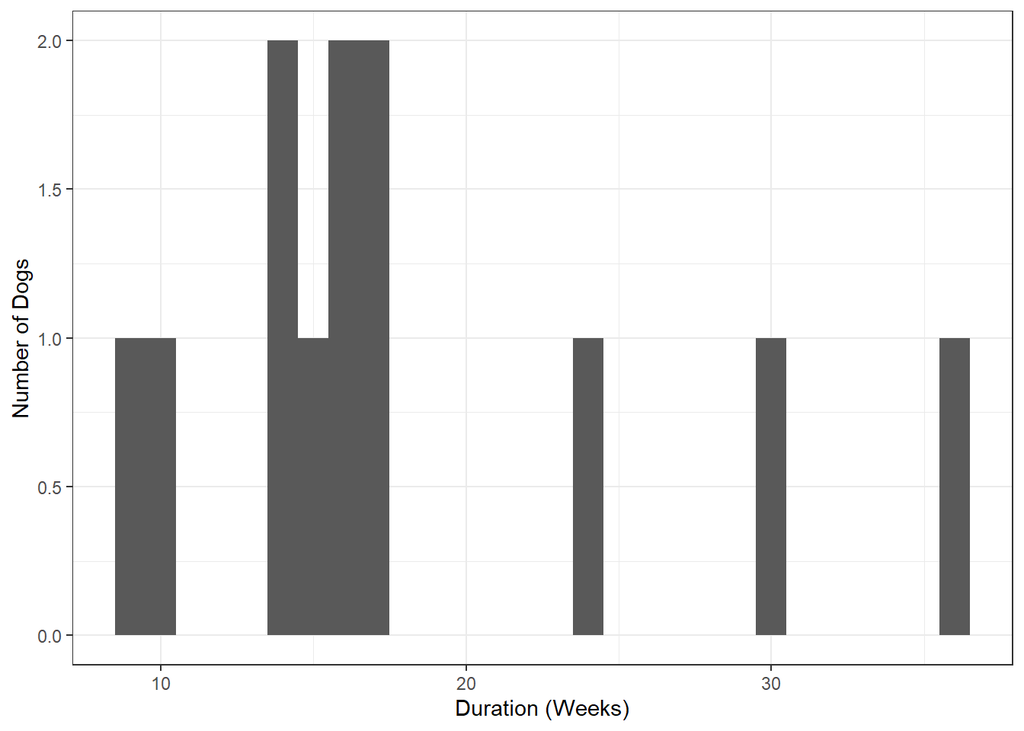

## 2.2 Descriptive Statistics

Calculate descriptive statistics for numerical and categorical variables.

```
##                                                     Min.   X1st.Qu.     Median
## Data.Collection.Number                          2.000000   2.000000   2.000000
## Duration                                       62.000000 142.000000 215.000000
## Familiarisation.Response..Oriented.to.Handler.  1.000000   1.000000   2.000000
## Familiarisation.Response..Exploration.          1.000000   4.000000   5.000000
## Familiarisation.Response..Waiting.              1.000000   1.000000   1.000000
## Call.Back.Response                              1.000000   1.000000   1.000000
## Walking.Distractibility                         1.000000   1.000000   2.000000
## Walking.Pull.on.leash                           1.000000   1.000000   2.000000
## Walking.Pull.strength                           1.000000   1.000000   1.500000
## Walking.Initiative                              1.000000   2.000000   2.000000
## Standing.Response                               1.000000   2.000000   3.000000
## Sitting.Response                                1.000000   2.000000   3.000000
## Lying.Response                                  1.000000   2.000000   3.000000
## Lying.Settled                                   1.000000   1.000000   3.000000
## Body.check.Table                                1.000000   3.000000   4.000000
## Body.check.Response                             1.000000   3.000000   3.000000
## Distractions.First.Response..Teddy.             1.000000   2.000000   3.000000
## Distractions.First.Response..Human.             2.000000   3.000000   3.000000
## Distractions.First.Response..Car.               1.000000   2.000000   3.000000
## Distractions.First.Response..Food.              1.000000   3.000000   4.000000
## Distractions.Second.Response..Teddy.            1.000000   1.000000   2.000000
## Distractions.Second.Response..Human.            1.000000   2.000000   3.000000
## Distractions.Second.Response..Car.              1.000000   2.000000   2.000000
## Distractions.Second.Response..Food.             1.000000   2.000000   3.000000
## Distractions.Pull.on.leash                      1.000000   2.000000   2.500000
## Distractions.Pull.strength                      1.000000   2.000000   3.000000
## Distractions.Human                              4.000000   4.000000   5.000000
## Kong.Presentation.Response                      2.000000   2.000000   4.000000
## Kong.Interaction.Response.to.stimulus           2.000000   3.000000   3.000000
## Kong.Interaction.Response.to.handler            1.000000   1.000000   1.000000
## Kong.Interaction.Back                           1.000000   1.000000   1.000000
## Kong.Return.Handler                             2.000000   2.000000   2.000000
## Dog.Response                                    1.000000   4.000000   5.000000
## Dog.Call.Back.Response                          1.000000   1.000000   1.000000
## Crate.Entering                                  1.000000   1.000000   1.000000
## Crate.Behaviours..Settled.                      1.000000   2.000000   3.000000
## Crate.Behaviours..Sniffing.Exploring..          1.000000   2.000000   2.000000
## Crate.Behaviours..Actively.Seeking.Attention.   1.000000   1.000000   1.000000
## Crate.Behaviours..Digging.                      1.000000   1.000000   1.000000
```

[output cut: 242 more lines]

```
## S.Crate.Stimulus_mean                             3.000000    0
## S.Crate.Stimulus_prod                            72.000000    0
## S.Crate.Handler_mean                              3.666667    0
## S.Crate.Handler_prod                             45.000000    0
## S.Petting.Stimulus.During_mean                    4.000000    1
## S.Petting.Stimulus.During_prod                   15.000000    0
## S.Petting.Engagement.During_mean                  3.000000    1
## S.Petting.Engagement.During_prod                  9.000000    0
## S.Petting.After_mean                              3.500000    1
## S.Petting.After_prod                             12.000000    0
## S.Isolation.Handler_mean                          4.000000    0
## S.Isolation.Handler_prod                         64.000000    0
## S.Isolation.Stimulus                              4.000000    0
## S.Sociability_mean                                5.000000    0
## S.Sociability_prod                              120.000000    0
```

```
## dataframe saved to  3_results/dc2-working/descriptive-statistics-numerical.csv
```

```
##                                                                  No Yes NA.s
## Body.check.General..Mouths.                                      60  60    0
## Body.check.General..Licks.                                       56   4    0
## Tea.Towel.First.Response..Indifferent.                           52   8    0
## Tea.Towel.First.Response..Change.from.Neutral.                    9  51    0
## Tea.Towel.First.Response..Turns.head.                            12  48    0
## Tea.Towel.First.Response..Attempts.to.Removes.towel.by.moving.   33  27    0
## Tea.Towel.First.Response..Attempts.to.Removes.towel.with.mouth.  33  27    0
## Tea.Towel.First.Response..Plays.                                 52   8    0
## Tea.Towel.Second.Response..Indifferent.                          38  22    0
## Tea.Towel.Second.Response..Turns.head.                           28  32    0
## Tea.Towel.Second.Response..Change.from.Neutral.                  21  39    0
## Tea.Towel.Second.Response..Attempts.to.Removes.towel.by.moving.  40  20    0
## Tea.Towel.Second.Response..Attempts.to.Removes.towel.with.mouth. 40  20    0
## Tea.Towel.Second.Response..Plays.                                53   7    0
## Crate.Urinating                                                  60  60    0
## Isolation.Urinating                                              59   1    0
```

```
## dataframe saved to  3_results/dc2-working/descriptive-statistics-categorical.csv
```

```
## dataframe saved to  3_results/dc2-working/descriptive-kong-lateralisation.csv
```

## 2.3 Validity

```
## Categorical variable with 3 factors: Other LR LRxGR
```

```
##
## Call:
## glm(formula = Working ~ x, family = binomial(link = logit), data = dc_cat,
##     na.action = na.exclude)
##
## Deviance Residuals:
##     Min       1Q   Median       3Q      Max
## -0.6681  -0.6681  -0.6231  -0.6231   1.8626
##
## Coefficients:
##             Estimate Std. Error z value Pr(>|z|)
## (Intercept)    16.57    2399.54   0.007    0.994
## xLR           -17.95    2399.54  -0.007    0.994
## xLRxGR        -18.11    2399.54  -0.008    0.994
##
## (Dispersion parameter for binomial family taken to be 1)
##
##     Null deviance: 60.048  on 59  degrees of freedom
## Residual deviance: 56.708  on 57  degrees of freedom
## AIC: 62.708
##
## Number of Fisher Scoring iterations: 15
```

```
## dataframe saved to  3_results/dc2-working/breed.csv
```

```
## Categorical variable with 4 factors: Both Left None Righ
```

```
##
## Call:
## glm(formula = Working ~ x, family = binomial(link = logit), data = dc_cat,
##     na.action = na.exclude)
##
## Deviance Residuals:
##     Min       1Q   Median       3Q      Max
## -1.0383  -0.6444  -0.4590  -0.4366   2.1899
##
## Coefficients:
##             Estimate Std. Error z value Pr(>|z|)
## (Intercept)  -0.3365     0.5855  -0.575   0.5655
## xLeft        -1.1299     0.8678  -1.302   0.1929
## xNone        -1.8608     0.9478  -1.963   0.0496 *
## xRigh        -1.9661     1.2010  -1.637   0.1016
## ---
## Signif. codes:  0 '***' 0.001 '**' 0.01 '*' 0.05 '.' 0.1 ' ' 1
##
## (Dispersion parameter for binomial family taken to be 1)
##
##     Null deviance: 56.760  on 58  degrees of freedom
## Residual deviance: 51.448  on 55  degrees of freedom
##   (1 observation deleted due to missingness)
## AIC: 59.448
##
## Number of Fisher Scoring iterations: 4
```

```
## dataframe saved to  3_results/dc2-working/lateralisation.csv
```

Positive estimates increase the probability of failure, while negative estimates decrease the probability of failure. Save results from univariate analysis.

```
## dataframe saved to  3_results/dc2-working/univariate-logistic-regression.csv
```

Converting logistic regression result to odds ratio and confidence intervals.

```
## dataframe saved to  3_results/dc2-working/lr.csv
```

## 2.4 Feature Selection

Metholodogy adapted from Hosmer2013, pg 107 (GLOW study example).

### 2.4.1 Step 1: Univariate logistic regression model results.

```
##                                                    p_value Significance
## Walking.Pull.on.leash                           0.02730000          ***
## Walking.Pull.strength                           0.02000000          ***
## Body.check.Table                                0.13980000            *
## Distractions.First.Response..Car.               0.02110000          ***
## Kong.Interaction.Response.to.stimulus           0.02780000          ***
## Kong.Return.Handler                             0.06500000           **
## Crate.Behaviours..Actively.Seeking.Attention.   0.07850000           **
## Crate.Behaviours..Whining.                      0.11990000            *
## Isolation.Response..Time.oriented.              0.03090000          ***
## Isolation.Response..Exploration.                0.04740000          ***
## S.Familiarisation.Handler_mean                  0.10380000            *
## S.Familiarisation.Handler_prod                  0.14580000            *
## S.Walking.Pull_mean                             0.01980000          ***
## S.Walking.Pull_prod                             0.02320000          ***
## S.Walking.Distractions.Pull_mean                0.06390000           **
## S.Sensitivity                                   0.09040000           **
## S.Kong.Response_prod                            0.14690000            *
## S.Crate.Handler_mean                            0.09240000           **
## S.Crate.Handler_prod                            0.13730000            *
## S.Isolation.Handler_mean                        0.04370000          ***
## S.Isolation.Stimulus                            0.02650000          ***
## Tea.Towel.Second.Response..Indifferent.         0.04770323          ***
## Tea.Towel.Second.Response..Change.from.Neutral. 0.05736182           **
## Sex                                             0.12928744            *
```

```
## [1] "Significance" "Estimate"     "p_value"      "OR"           "2.5 %"
## [6] "97.5 %"
```

```
##                                          Estimate    p_value
## Walking.Pull.on.leash                   -1.435100 0.02730000
## Walking.Pull.strength                   -1.899300 0.02000000
## Distractions.First.Response..Car.        0.790800 0.02110000
## Kong.Interaction.Response.to.stimulus    2.155400 0.02780000
## Isolation.Response..Time.oriented.      -0.711300 0.03090000
## Isolation.Response..Exploration.         0.602900 0.04740000
## S.Walking.Pull_mean                     -1.719900 0.01980000
## S.Walking.Pull_prod                     -0.573900 0.02320000
## S.Isolation.Handler_mean                -1.231600 0.04370000
## S.Isolation.Stimulus                     0.601800 0.02650000
## Tea.Towel.Second.Response..Indifferent. -2.146581 0.04770323
```

```
## [1] 6
```

### 2.4.2 Step 2: Correlation

```
## character(0)
```

[figure not shown]

```
##
##  Pearson's Chi-squared test with Yates' continuity correction
##
## data:  data_1$Tea.Towel.Second.Response..Indifferent. and data_1$Tea.Towel.Second.Response..Change.from.Neutral.
## X-squared = 36.797, df = 1, p-value = 1.311e-09
```

## 2.5 Missing Data

dc2, missing values per column and per row. Very few data are missing considering the original items selected.

```
##                                 Working                     S.Walking.Pull_mean
##                                       0                                       0
##                           S.Sensitivity                    S.Kong.Response_prod
##                                       0                                       0
##                    S.Crate.Handler_mean                    S.Isolation.Stimulus
##                                       0                                       0
##                S.Isolation.Handler_mean          S.Familiarisation.Handler_mean
##                                       0                                       1
## Tea.Towel.Second.Response..Indifferent.       Distractions.First.Response..Car.
##                                       0                                       0
```

```
## dc_row_nas
##  0  1
## 59  1
```

## 2.6 Visualization

```
## Plot these features manually:  Tea.Towel.Second.Response..Indifferent.
```

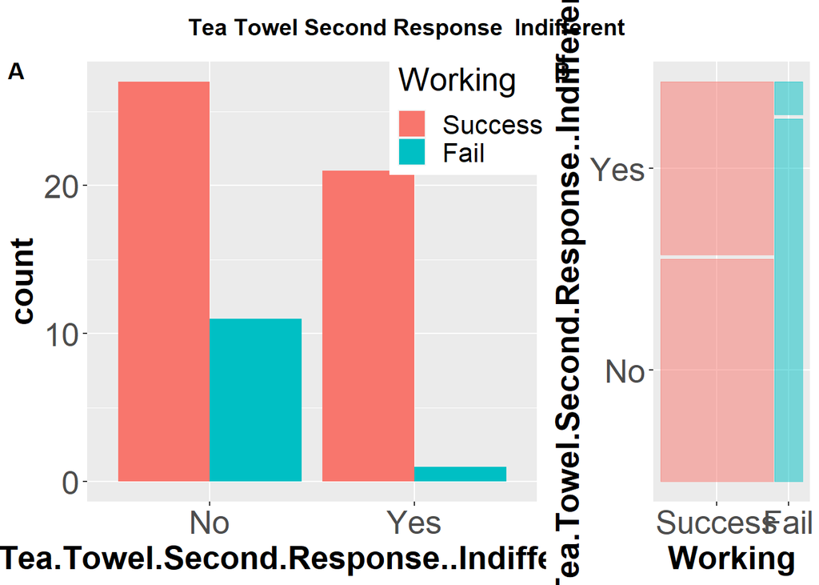

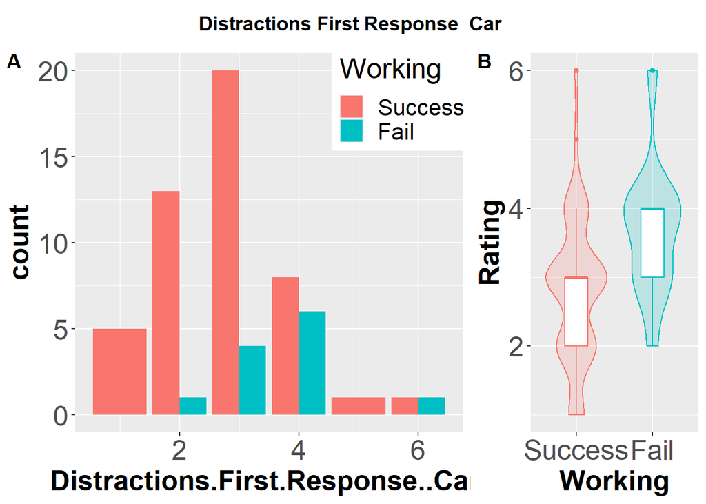

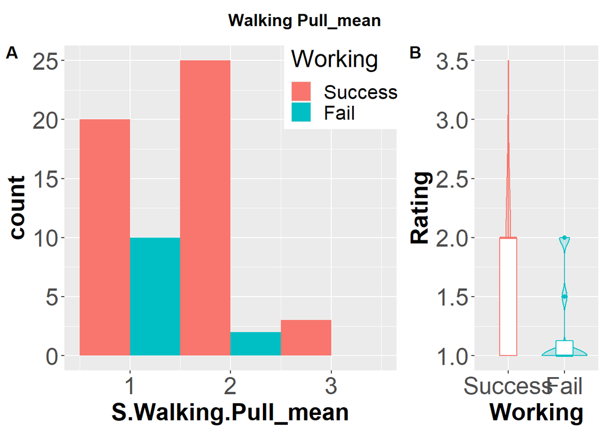

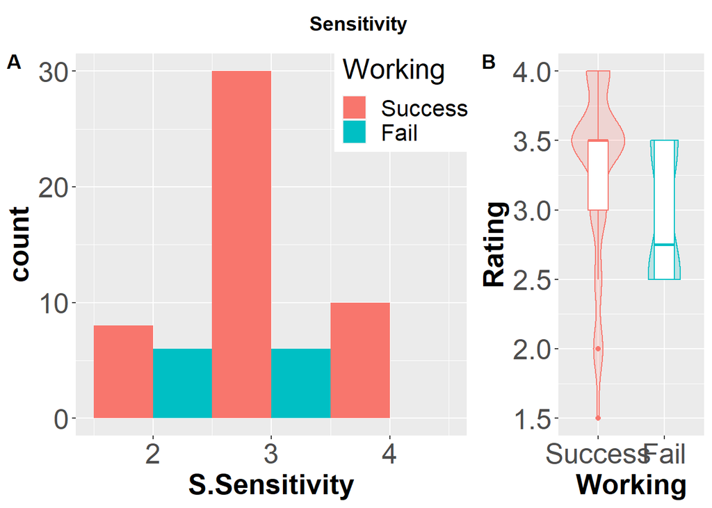

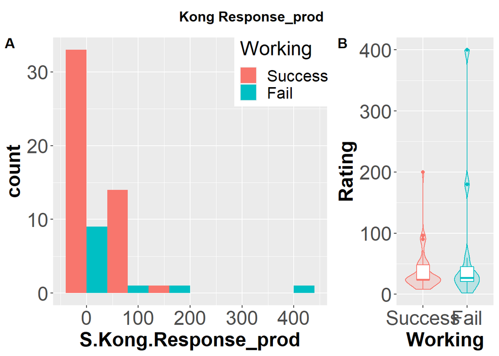

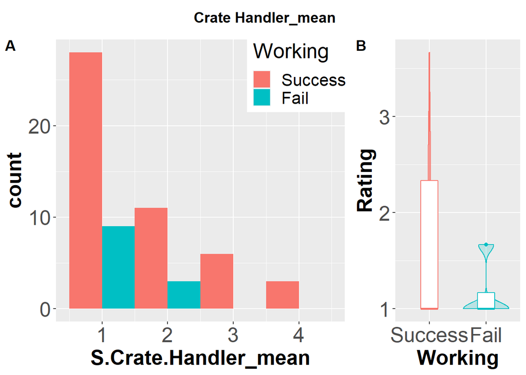

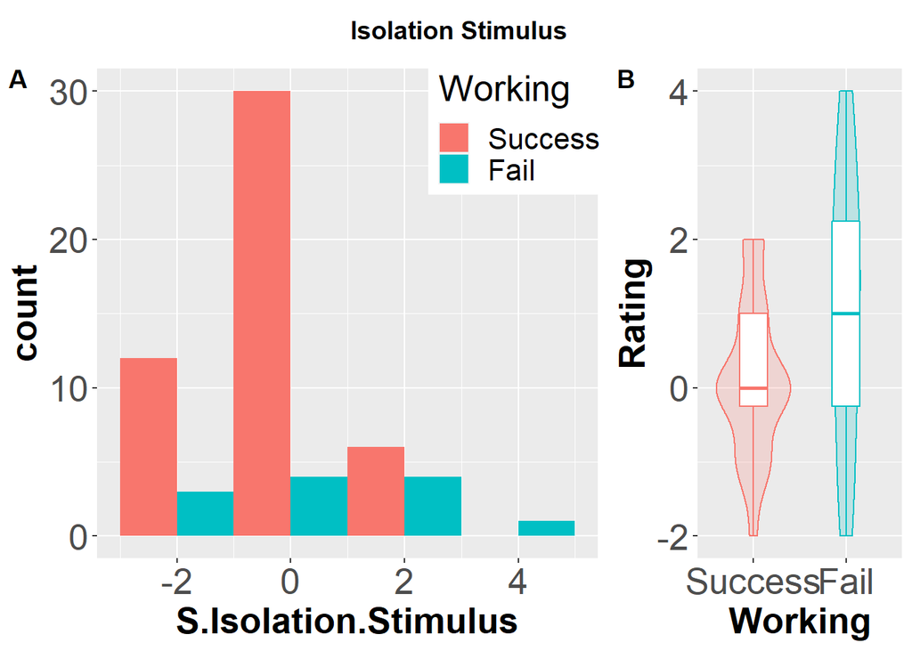

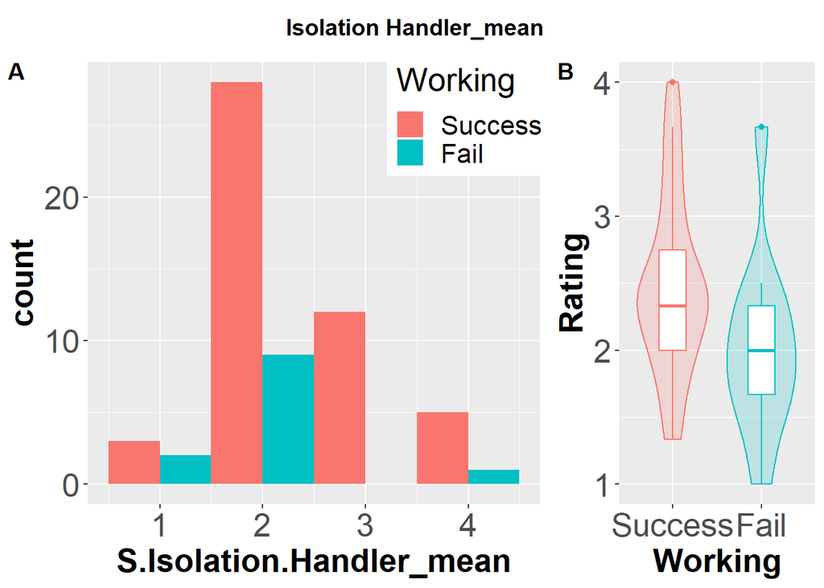

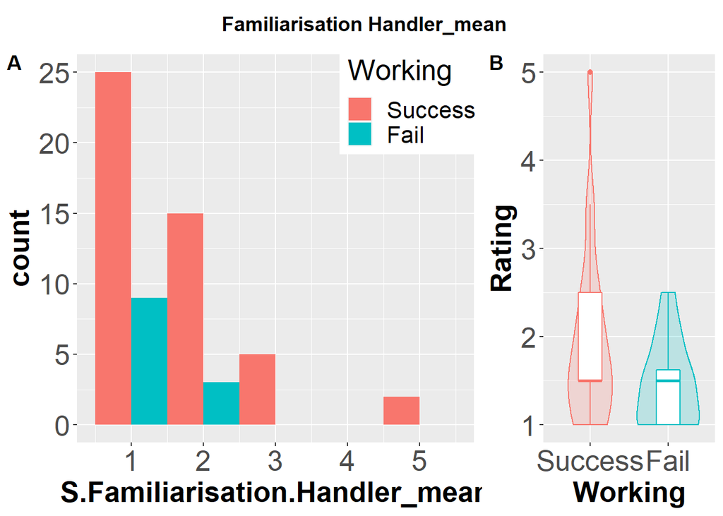

# 3 Multivariate Model

Preprocessing: Normalization + Imputation. Recursive Feature Elimination (RFE) + Multivariate Logistic Regression (LR). Build model.

```
##  [1] "Working"
##  [2] "S.Walking.Pull_mean"
##  [3] "S.Sensitivity"
##  [4] "S.Kong.Response_prod"
##  [5] "S.Crate.Handler_mean"
##  [6] "S.Isolation.Stimulus"
##  [7] "S.Isolation.Handler_mean"
##  [8] "S.Familiarisation.Handler_mean"
##  [9] "Tea.Towel.Second.Response..Indifferent."
## [10] "Distractions.First.Response..Car."
```

```
## predicting second class: Fail Success
```

```
##
## Recursive feature selection
##
## Outer resampling method: Cross-Validated (60 fold)
##
## Resampling performance over subset size:
##
##  Variables AUC Precision Recall   F AUCSD PrecisionSD RecallSD FSD
##          1 NaN    0.0000 0.0000 NaN    NA      0.0000   0.0000  NA
##          2 NaN    0.5000 0.4167   1    NA      0.5270   0.5149   0
##          3 NaN    0.3750 0.2500   1    NA      0.5175   0.4523   0
##          4 NaN    0.6154 0.6667   1    NA      0.5064   0.4924   0
##          5 NaN    0.4615 0.5000   1    NA      0.5189   0.5222   0
##          6 NaN    0.6667 0.6667   1    NA      0.4924   0.4924   0
##          7 NaN    0.6154 0.6667   1    NA      0.5064   0.4924   0
##          8 NaN    0.5833 0.5833   1    NA      0.5149   0.5149   0
##          9 NaN    0.5833 0.5833   1    NA      0.5149   0.5149   0
##  Num_Resamples Selected
##             60
##             60
##             60
##             60
##             60
##             60        *
##             60
##             60
##             60
##
## The top 5 variables (out of 6):
##    Distractions.First.Response..Car., S.Walking.Pull_mean, S.Familiarisation.Handler_mean, S.Isolation.Stimulus, S.Crate.Handler_mean
```

```
##
## Call:
## glm(formula = Class ~ ., family = "binomial", data = tmp)
##
## Deviance Residuals:
##      Min        1Q    Median        3Q       Max
## -3.05833   0.02044   0.13882   0.35847   1.26654
##
## Coefficients:
##                                   Estimate Std. Error z value Pr(>|z|)
## (Intercept)                         3.2589     0.9544   3.414 0.000639 ***
## Distractions.First.Response..Car.  -1.4313     0.6304  -2.271 0.023177 *
## S.Walking.Pull_mean                 1.8767     0.8158   2.300 0.021425 *
## S.Familiarisation.Handler_mean      1.5885     0.9013   1.763 0.077974 .
## S.Isolation.Stimulus               -0.6597     0.5529  -1.193 0.232817
## S.Crate.Handler_mean                1.1282     1.0008   1.127 0.259617
## S.Sensitivity                       0.4760     0.4326   1.101 0.271113
## ---
## Signif. codes:  0 '***' 0.001 '**' 0.01 '*' 0.05 '.' 0.1 ' ' 1
##
## (Dispersion parameter for binomial family taken to be 1)
##
##     Null deviance: 60.048  on 59  degrees of freedom
## Residual deviance: 29.057  on 53  degrees of freedom
## AIC: 43.057
##
## Number of Fisher Scoring iterations: 7
```

Model fitness with deviance analysis.

```
##
## deviance difference:  30.9913
```

```
##
## df difference:  6
```

```
##
## level of significance:  2.544646e-05
```

```
##
## the model is a good fit:  TRUE
```

## 3.1 Performance

Performance metrics ROC and PR curves.

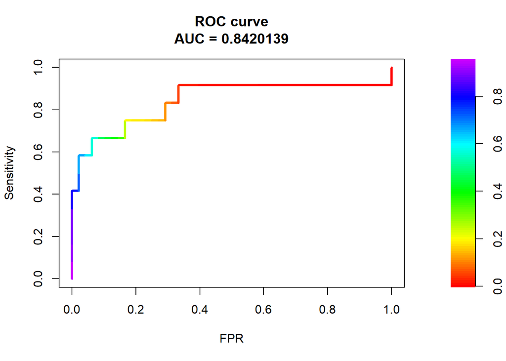

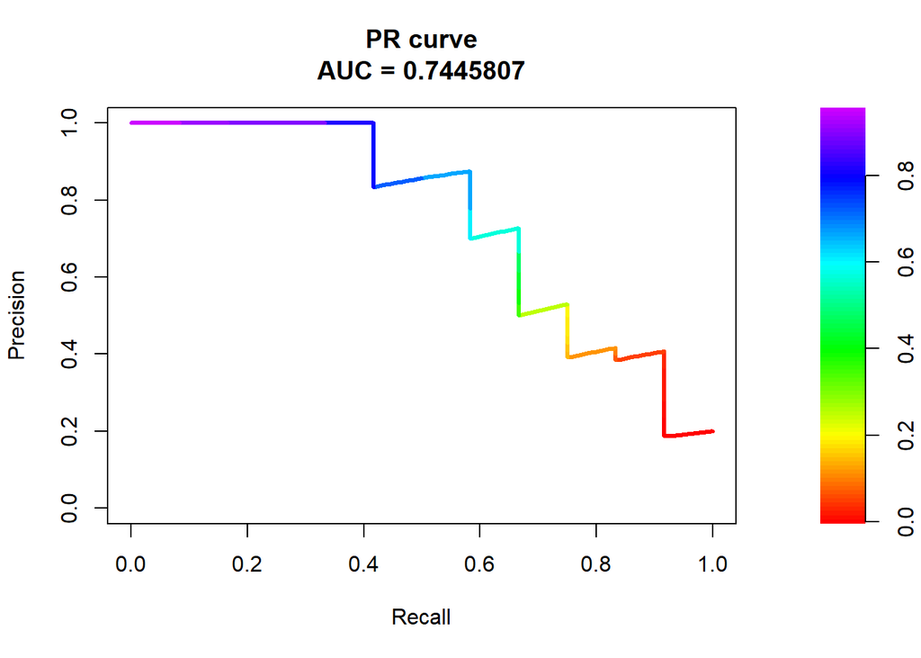

```
##          Accuracy   ROC    PR Precision Recall Sensitivity Specificity    F1
## Accuracy    0.867 0.842 0.745     0.667  0.667       0.667       0.917 0.667
##          Balanced.Accuracy
## Accuracy             0.792
```

Plot the logit.

```
## [1] "Probability predicted by the LR using PRQ data vs true Working"
```

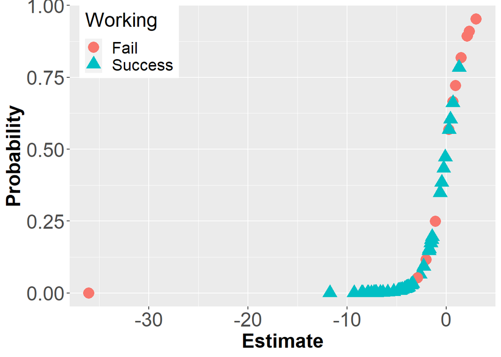

```
## [1] "Probability predicted by the LR using PRQ data vs true Status"
```

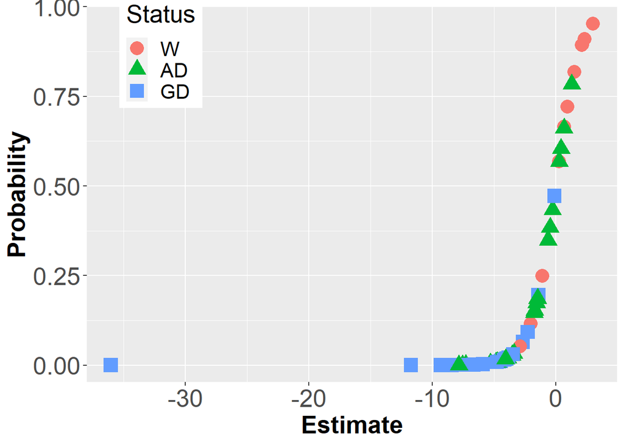

```
## [1] "Estimate and Probabilities per training outcome status"
```

```
## # A tibble: 3 × 3
##   Status   Mean    SD
##   <fct>   <dbl> <dbl>
## 1 W       0.635  1.91
## 2 AD     -2.69   2.75
## 3 GD     -6.37   6.46
```

```
## # A tibble: 3 × 3
##   Status   Mean     SD
##   <fct>   <dbl>  <dbl>
## 1 W      0.622  0.333
## 2 AD     0.216  0.251
## 3 GD     0.0379 0.0958
```

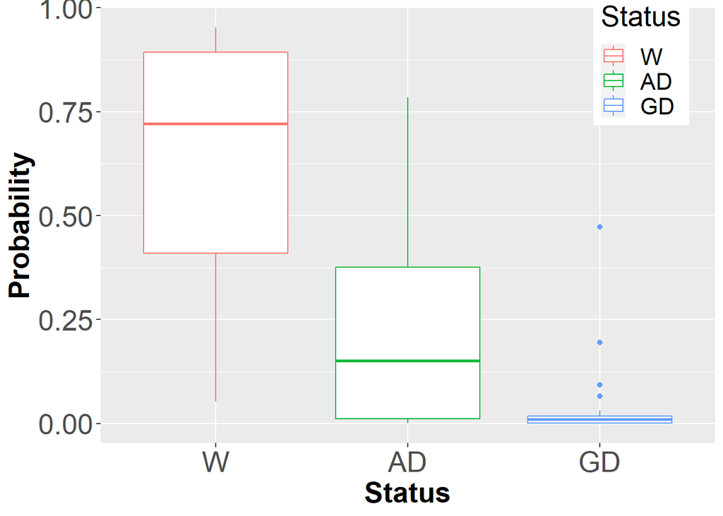

```
##
##  Kruskal-Wallis rank sum test
##
## data:  Probability by Status
## Kruskal-Wallis chi-squared = 26.239, df = 2, p-value = 2.005e-06
```

```
##
##  Pairwise comparisons using Wilcoxon rank sum exact test
##
## data:  df_perf$Probability and df_perf$Status
##
##    W       AD
## AD 0.00069 -
## GD 7.5e-08 0.00215
##
## P value adjustment method: none
```

Check the dogs that were false positives or false negatives

```
## [1] Lexie Jane  Gav   Harry
## 61 Levels: Douglas Dugg Earl Ebbi Eddie Edrick Effie Eldin Elf Eliza ... Zodiac
```

```
## [1] Herbie Zander Meg    Hayley
## 61 Levels: Douglas Dugg Earl Ebbi Eddie Edrick Effie Eldin Elf Eliza ... Zodiac
```

## 3.2 Interpretation

Discuss model interpretation.

```
##                                     Estimate      P-value         OR
## (Intercept)                       -3.2588999 0.0006391233 0.03843065
## Distractions.First.Response..Car.  1.4313388 0.0231766222 4.18429718
## S.Walking.Pull_mean               -1.8766677 0.0214247804 0.15309942
## S.Familiarisation.Handler_mean    -1.5885370 0.0779737267 0.20422417
## S.Isolation.Stimulus               0.6597031 0.2328174141 1.93421805
## S.Crate.Handler_mean              -1.1281667 0.2596169949 0.32362603
## S.Sensitivity                     -0.4760262 0.2711134151 0.62124718
##                                         2.5 %     97.5 %
## (Intercept)                       0.003544481  0.1682605
## Distractions.First.Response..Car. 1.392694363 18.1627967
## S.Walking.Pull_mean               0.021390502  0.5745406
## S.Familiarisation.Handler_mean    0.023415702  0.7685348
## S.Isolation.Stimulus              0.713666926  6.7925131
## S.Crate.Handler_mean              0.031701368  1.7523020
## S.Sensitivity                     0.252166160  1.4876941
```

```
## dataframe saved to  3_results/dc2-working/rfe-lr.csv
```

Descriptive statistics and univariate models for the features of the optimal model.

```
## dataframe saved to  3_results/dc2-working/descriptive-optimal-variables.csv
```

```
## dataframe saved to  3_results/dc2-working/lr-optimal-variables.csv
```

Variable importance of logistic regression models is calculated based on the absolute value of the t-statistic.

```
## dataframe saved to  3_results/dc2-working/feature-importance.csv
```

# 4 Conclusion